# Projekt R (Statystyka Opisowa i Ekonomiczna)

Jakub Anczyk

2022-05-30

## Temat projektu: Relacja między religijnością a wolnością

Na temat projektu idnywidualnego wybrałem zbadanie relacji między religijnością populacji wybranych państw i regionów według odsetka populacji, który identyfikuje się z dowolną religią a wolnością, mierzoną wskaźnikami oceniającymi proces wyborczy, pluralizm polityczny i partycypację, funkcjonowanie rządu, wolność słowa i przekonań, prawa stowarzyszania się i organizowania, rządy prawa oraz autonomię osobistą i prawa jednostki.

Postaram się odpowiedzieć na następujące pytanie: **“Czy istnieją wyznania, które jako dominujące w kraju lub regionie, mogą sygnalizować problemy z demokracją lub swobodami obywatelskimi?”

W projekcie wykorzystałem publicznie dostępne dane z dwóch źródeł:

1. Dane dotyczące religijności pochodzą ze strony projektu [Correlates of War](https://correlatesofwar.org/). Zbiór danych jest dostępny pod [następującym linkiem](https://correlatesofwar.org/data-sets/world-religion-data/wrp-global-data/at_download/file/WRP_national.csv).
2. Dane o wolności pochodzą ze strony projektu [Freedom House](https://freedomhouse.org/report/freedom-world). Zbiór danych jest dostępny pod [następującym linkiem](https://freedomhouse.org/sites/default/files/2022-02/Aggregate_Category_and_Subcategory_Scores_FIW_2003-2022.xlsx).

Dla ułatwienia wizualizacji danych, różne formy wyznań zgrupowano w ogólniejsze zbiory. Ostatecznie wziąłem pod wagę następujące grupy wyznań: chrześcijaństwo, judaizm, islam, buddyzm, zoroastrianizm, hinduizm, sikhizm, shintoizm, bahaizm, taoizm, dźinizm, konfucjanizm, synkretyzm, ateizm i “inne”.

## Analiza zależności między swobodą polityczną a wyznaniem

Jak nietrudno zauważyć na poniższym przykładzie, występuje znaczne zróżnicowanie między dominującą w kraju religią a łącznym wynikiem w kategorii “swobody polityczne” według Freedom House. Definicja tego pojęcia znajduje się pod [następującym linkiem](https://freedomhouse.org/reports/freedom-world/freedom-world-research-methodology).

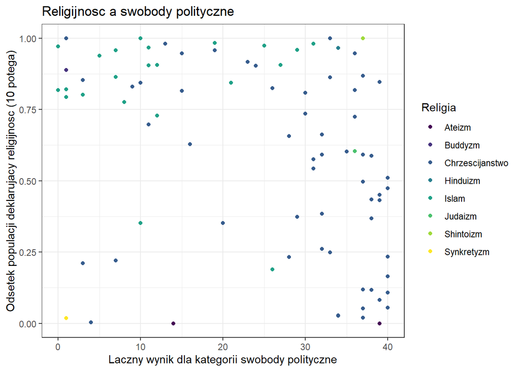

## Analiza zależności między swobodą obywatelską a wyznaniem

Jak pokazuje poniższy przykład, prawidłowość ta występuje również w przypadku wyniku w kategorii “swobód obywatelskich”. Definicja pojęcia znajduje się pod [następującym linkiem](https://freedomhouse.org/reports/freedom-world/freedom-world-research-methodology).

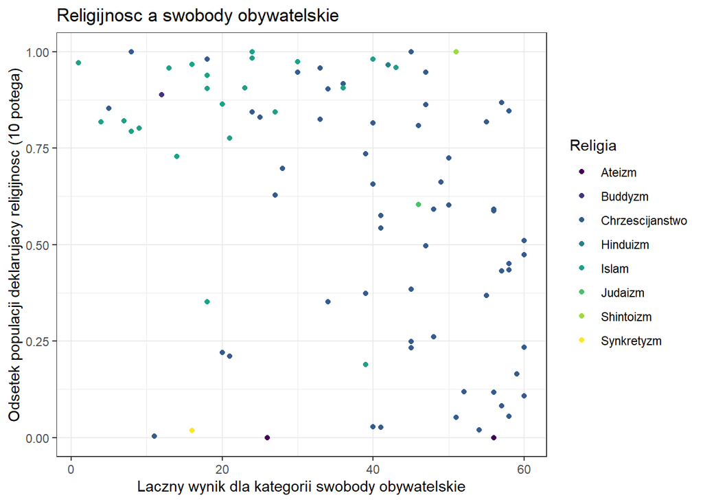

Idąc dalej, można także porównać średni wynik w kategorii “swobody polityczne” oraz “swobody obywatelskie” według Freedom House w kontekście:

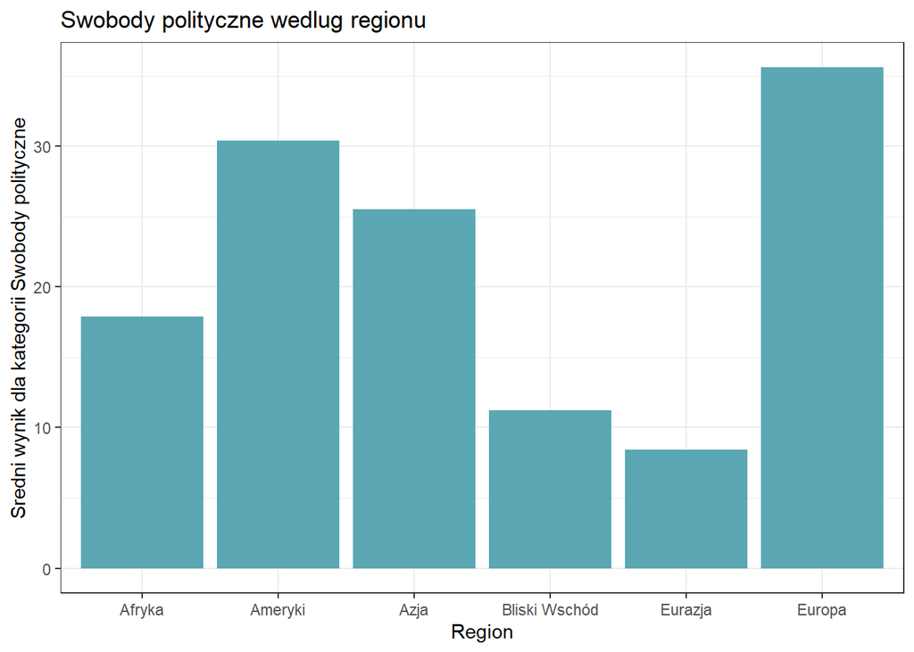

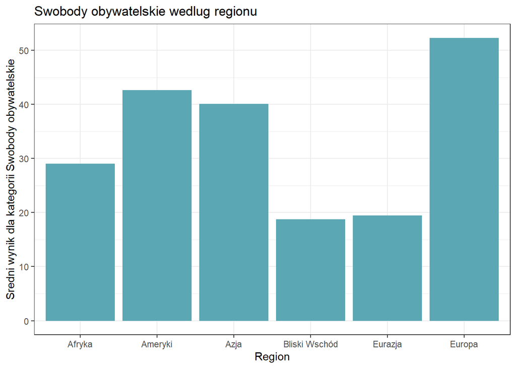

W tym miejscu warto jednak zaznaczyć, że ateizm jest dominującą formą wyznania (lub raczej jej braku) wyłącznie w dwóch krajach: Estonii i Korei Północnej.

Najniższe wyniki w zestawieniu osiągają kraje, w których dominującym wyznaniem są islam (większość Afryki oraz Bliski Wschód), buddyzm (Laos) lub synkretyzm (Chiny).

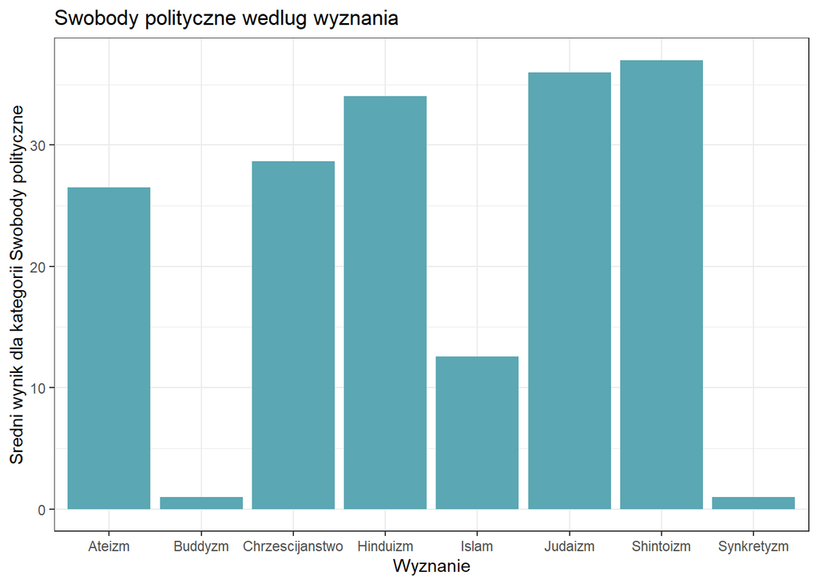

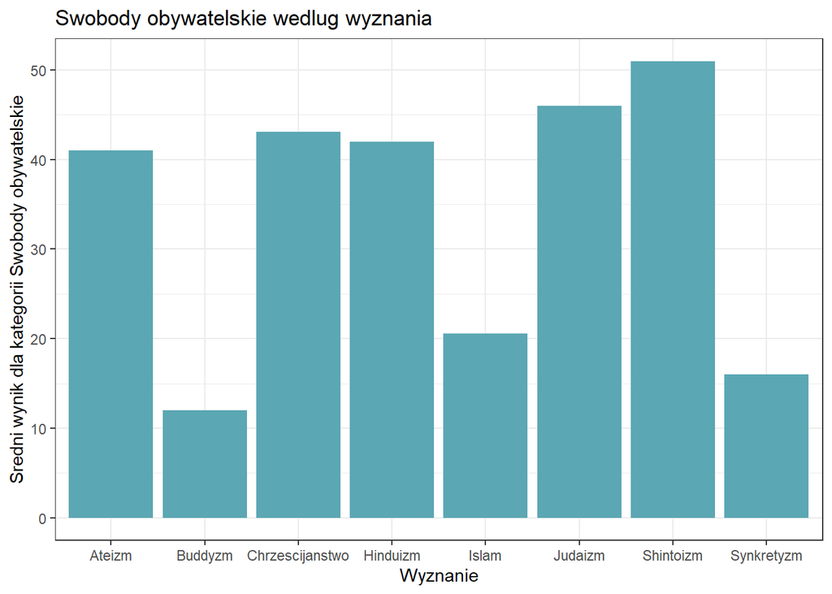

## Analiza zależności między swobodą polityczną a religijnością

Suma indeksu swobód obywatelskich i politycznych przedstawia się następująco.

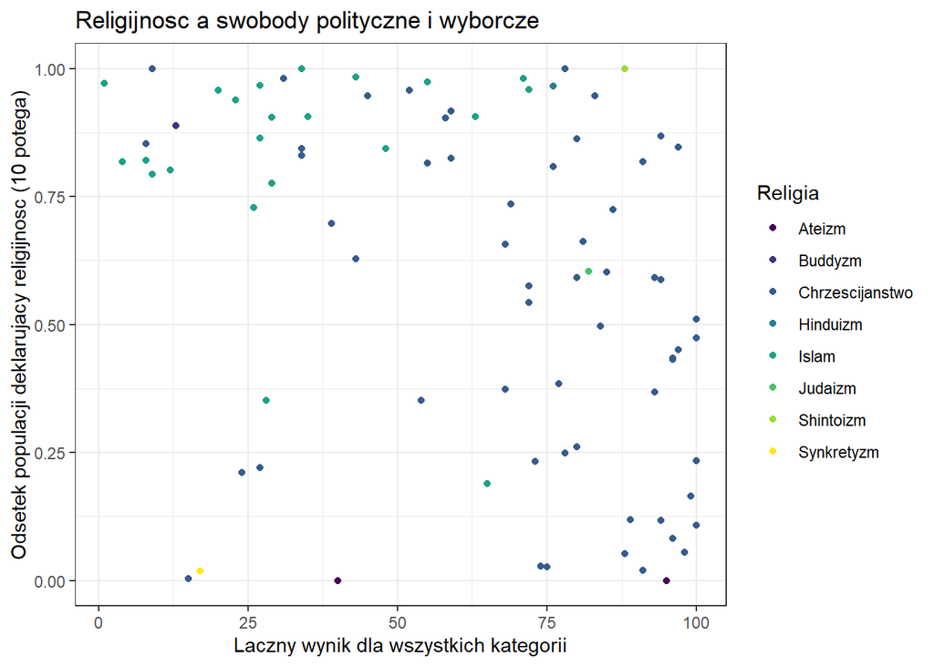

## Struktura wyznaniowa państw według regionu

Struktura religijna większości regionów zdominowana jest przez chrześcijan, z wyłączeniem Bliskiego Wschodu oraz Azji. Z uwagi jednak na liczbę mieszkańców tej ostatniej, globalny rozkład poszczególnych grup wyznaniowych nie jest zdominowany przez tę grupę wyznaniową.

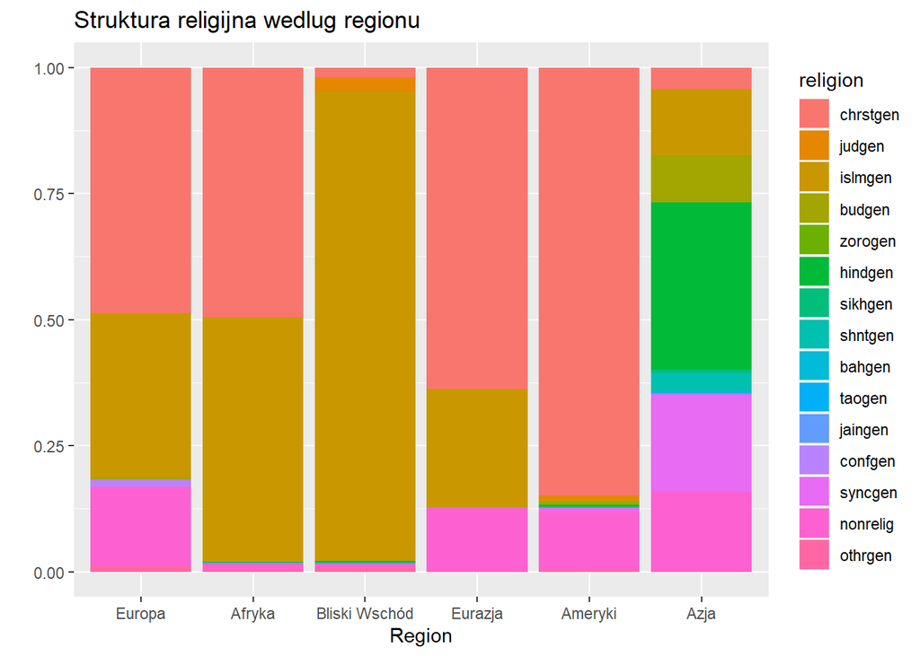

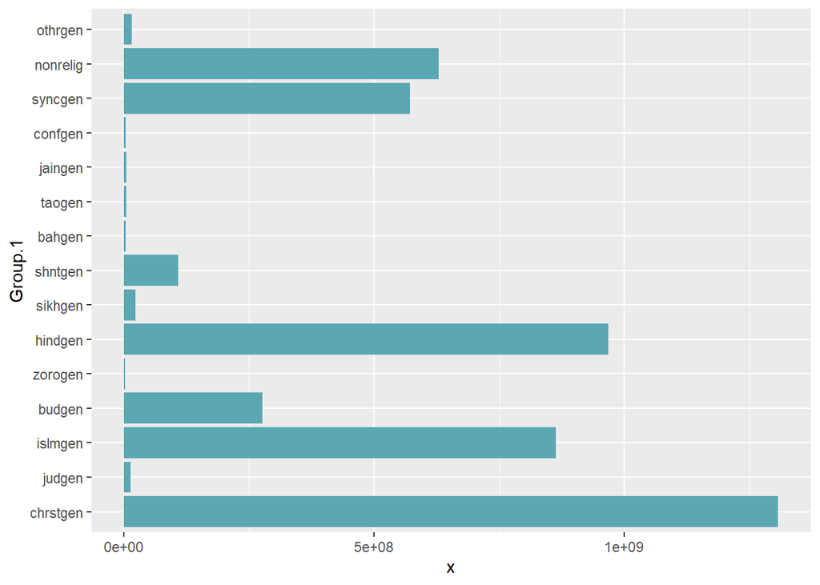

## Wnioski: łączny wynik indeksu swobód obywatelskich i politycznych według państwa i dominującego wyznania

Poniższy wykres wskazuje wyraźnie, iż indeks swobód obywatelskich i politycznych jest najwyższy w krajach chrześciańskich, z nielicznymi wyjątkami. Najniższe z reguły występują w krajach, w których dominującą religią jest islam bądź rzadkie religie występujące wyłącznie na wschodzie.

Niezależnie od przyczyn stanu rzeczy, państwa, w których dominującą religią jest któraś z form chrześcijaństwa, dużo częściej osiągają wysokie wyniki indeksu swobód obywatelskich i politycznych. Odwrotna prawidłowość występuje dla krajów, w których dominuje islam.

Prawdopodobnym wyjaśnieniem tego zjawiska jest idea demokracji rozwijana w państwach zachodnich, która pośrednio przez wiele lat tłumiła zapędy religijnych demagogów, ale także tendencja demokratycznych społeczeństw do stawania się z czasem coraz bardziej liberalnymi (Ethan Zell, Michael J. Bernstein, 2013).

Demokracja w pozostałej częsci świata wcale nie jest domyślnym systemem politycznym i zapewne przez długi czas nie będzie. Fakt ten dobitnie obrazuje ostry skręt w stronę politycznego ekstremizmu i radykalizmu mniejszych azjatyckich republik i podział świata na strefę wpływów garstki mocarstw, z których Chiny i Rosja bynajmniej nie zamierzają zwiększać swobód obywatelskich i politycznych swoich obywateli.

Dodatkowo skomplikowane dzieje państwowości Bliskiego Wschodu i Afryki, które przez stulecia padały ofiara zachodniego imperializmu, mogły w znacznym stopniu przyczynić się do obecnej sytuacji. W tym kontekście wypadałoby zbadać także istnienie korelacji między indeksem a przeszłością kolonialną wybranych krajów.

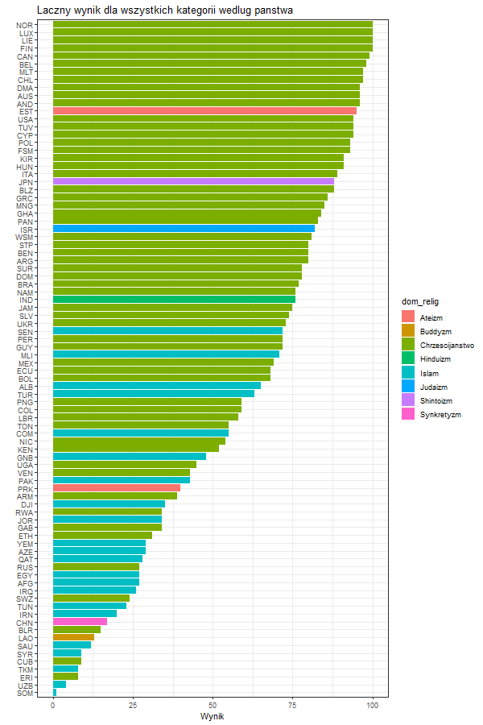

“Łączny wynik dla wszystkich kategorii według państwa”